# Lab5

Soyeon Lee

3/18/2021

Problems In the context of making decisions about whether or not observed data is consistent or inconsistent with a Null hypothesis, it is possible to make errors. The questions below ask you to create simulated data containing patterns that could lead to correct and incorrect decisions about the role of the null hypothesis.

Consider a design with 3 groups, and 10 people per group. Assume that the dependent variable is assumed to be normally distributed, and use unit normal distributions with mean = 0, and sd = 1 in your simulations.

1. Create simulated data for the above design that could be produced by the null hypothesis, and that results in a F value that is smaller than the critical value for F in this design (assume alpha = .05). Report the ANOVA, and show a ggplot of the means in the simulated data. Furthermore, display the individual data points on top of the means. Would you reject the null hypothesis in this situation, and would you be incorrect or correct in rejecting the null? (3 points) Independence: 50

```r
library(tibble)

# a loop to guarantee a correct decision
levels <- 3
n_per_level <- 10

critical_F<-qf(.95, levels-1, levels*n_per_level-3 )

#repeat until we find the data that meets the criterion
repeat {
  random_data <- tibble(subjects = 1:(levels*n_per_level),
                      IV = as.factor(rep(1:levels,
                                         each = n_per_level)),
                      DV = rnorm(levels*n_per_level, 0, 1))

  aov.out <- aov(DV ~ IV, data = random_data)
  simulated_F <- summary(aov.out)[[1]]$`F value`[1]
    if(simulated_F < critical_F) {
      print(paste("failed to reject, the F-value is",
                  round(simulated_F,3)))
      break
    }
}
```

```
## [1] "failed to reject, the F-value is 0.245"
```

```r
# report the ANOVA
summary(aov.out)
```

```
##             Df Sum Sq Mean Sq F value Pr(>F)
## IV           2  0.469  0.2343   0.245  0.784
## Residuals   27 25.814  0.9561
```

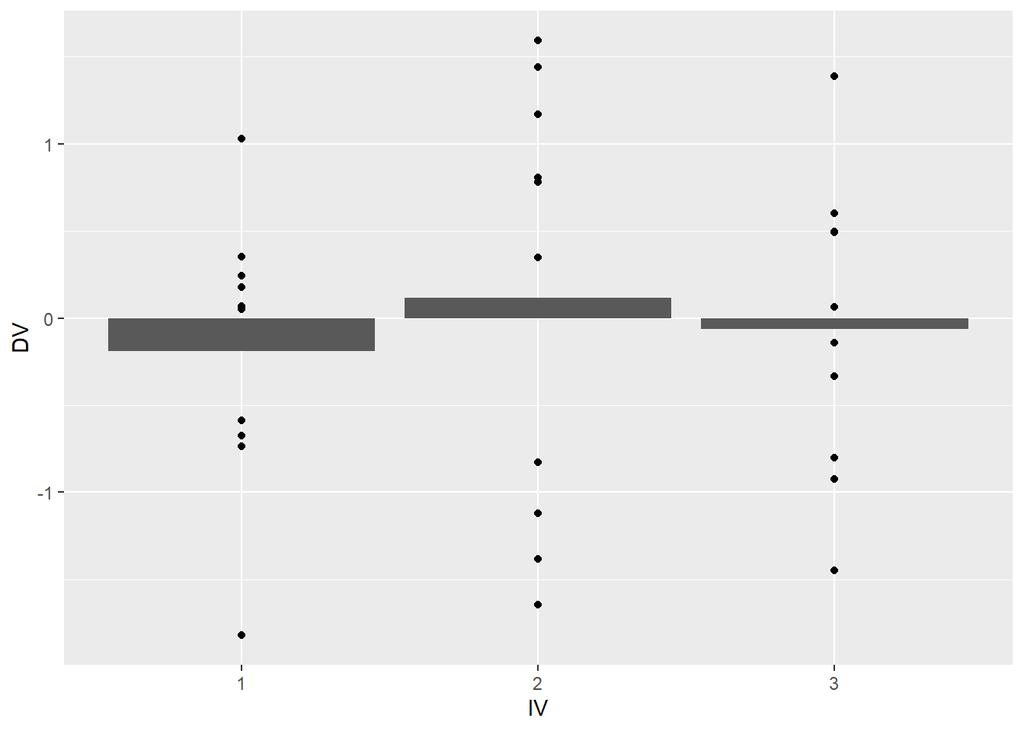

```r
#ggplot of the means with individual data points
library(ggplot2)

ggplot(random_data, aes(x=IV, y=DV))+
  geom_bar(stat="summary", fun="mean", position="dodge")+
  geom_point()
```

2. Create simulated data for the above design that could be produced by the null hypothesis, and that results in a F value that is larger than the critical value for F in this design (assume alpha = .05). Report the ANOVA, and show a ggplot of the means in the simulated data. Furthermore, display the individual data points on top of the means. Would you reject the null hypothesis in this situation, and would you be incorrect or correct in rejecting the null? (3 points) Independence: 50

```r
# a loop to guarantee a correct decision
levels <- 3
n_per_level <- 10

critical_F<-qf(.95, levels-1, levels*n_per_level-3 )

#repeat until we find the data that meets the criterion
repeat {
  random_data <- tibble(subjects = 1:(levels*n_per_level),
                      IV = as.factor(rep(1:levels,
                                         each = n_per_level)),
                      DV = rnorm(levels*n_per_level, 0, 1))

  aov.out <- aov(DV ~ IV, data = random_data)
  simulated_F <- summary(aov.out)[[1]]$`F value`[1]
    if(simulated_F > critical_F) {
      print(paste("reject the null, the F-value is",
                  round(simulated_F,3)))
      break
    }
}
```

```
## [1] "reject the null, the F-value is 3.51"
```

```r
# report the ANOVA
summary(aov.out)
```

```
##             Df Sum Sq Mean Sq F value Pr(>F)
## IV           2  11.40   5.702    3.51 0.0441 *
## Residuals   27  43.85   1.624
## ---
## Signif. codes:  0 '***' 0.001 '**' 0.01 '*' 0.05 '.' 0.1 ' ' 1
```

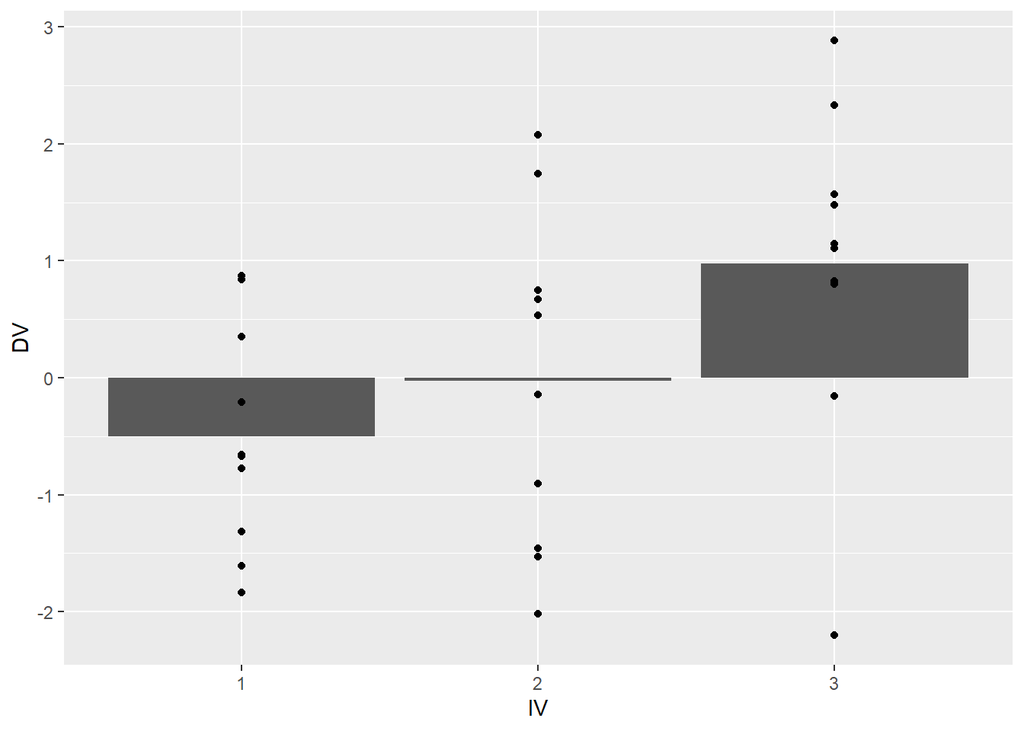

```r
#ggplot of the means with individual data points
library(ggplot2)

ggplot(random_data, aes(x=IV, y=DV))+
  geom_bar(stat="summary", fun="mean", position="dodge")+
  geom_point()
```

Bonus Question

3. In the lab we saw that F-distribution is robust to violations of the assumptions of ANOVA. For example, the simulation of the null based on a bi-modal distribution was very similar to the true F distribution. For this bonus question, show that you can “break” the F-distribution. Specifically, can you run a simulation that samples numbers from a non-normal distribution that does produce a very different looking F-distribution? (3 points) Independence:1

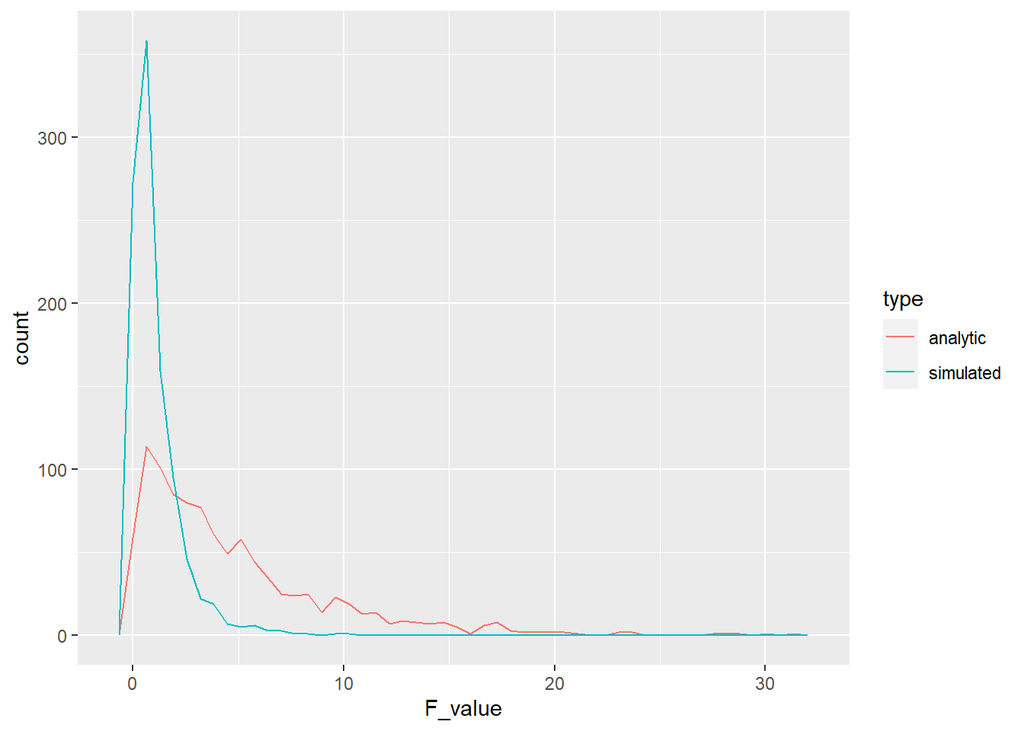

```r
levels<-3
n_per_level<-10

save_F_values <- length(1000)
for(i in 1:1000){
  random_data <- tibble(subjects = 1:(levels*n_per_level),
                      IV = as.factor(rep(1:levels, each = n_per_level)),
                      DV = rnorm(levels*n_per_level, 0, 1)
                      )
  aov.out <- aov(DV ~ IV, data = random_data)
  simulated_F <- summary(aov.out)[[1]]$`F value`[1]
  save_F_values[i] <- simulated_F
}

library(ggplot2)

F_comparison <- tibble(type = rep(c("analytic","simulated"),
                                  each = 1000),
                       F_value = c(rweibull(n=1000,shape=1,scale=5),
                                   save_F_values))

ggplot(F_comparison, aes(x=F_value, color=type))+
  geom_freqpoly(bins=50)
```

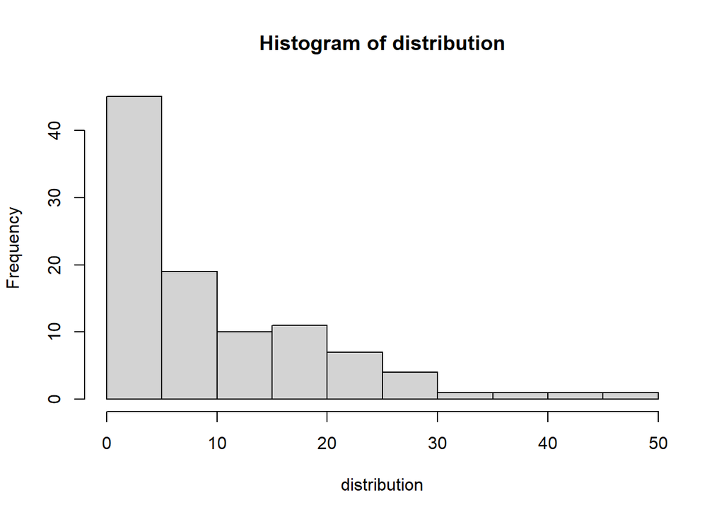

```r
distribution<-rweibull(100,1,10)
hist(distribution)
```